# Infer ASVs with DADA2

Andrea Martinez

April 23, 2024

# Before you start

## Set my seed

```r
# Any number can be chosen
set.seed(0601)
```

# Goals of this file

1. Use raw fastq files and generate quality plots to assess quality of reads.
2. Filter and trim out bad sequences and bases from our sequencing files.
3. Write out fastq files with high quality sequences.
4. Evaluate the quality from our filter and trim.
5. Infer Errors on forward and reverse reads individually.
6. Identified ASVs on forward and reverse reads separately, using the error model.
7. Merge forward and reverse ASVs into “contiguous ASVs”.
8. Generate the ASV count table. (`otu_table` input for phyloseq.).

Outputs of this file: 1. ASV Count Table: `otu_table`  
2. Taxonomy Table `tax_table` 3. Sample Information: `sample_data` track the reads lots throughout DADA2 workflow.

# Load Libraries

```r
# Efficient package loading with pacman
# Don't forget to install pacman and DT if you don't have it yet. :)
pacman::p_load(tidyverse, BiocManager, devtools, dada2,
               phyloseq, patchwork, DT, iNEXT, vegan,
               install = FALSE)
```

#Load data

```r
# Set the raw fastq path to the raw sequencing files
# Path to the fastq files
raw_fastqs_path <- "data/01_DADA2/raw_fastqs"
raw_fastqs_path
```

```
## [1] "data/01_DADA2/raw_fastqs"
```

```r
# What files are in this path?
head(list.files(raw_fastqs_path))
```

```
## [1] "SRR21916202_1.fastq.gz" "SRR21916202_2.fastq.gz" "SRR21916203_1.fastq.gz"
## [4] "SRR21916203_2.fastq.gz" "SRR21916204_1.fastq.gz" "SRR21916204_2.fastq.gz"
```

```r
# How many files are there?
str(list.files(raw_fastqs_path))
```

```
##  chr [1:72] "SRR21916202_1.fastq.gz" "SRR21916202_2.fastq.gz" ...
```

```r
# Create vector of forward reads
forward_reads <- list.files(raw_fastqs_path, pattern = "_1.fastq.gz", full.names = TRUE)
# Intuition Check
head(forward_reads)
```

```
## [1] "data/01_DADA2/raw_fastqs/SRR21916202_1.fastq.gz"
## [2] "data/01_DADA2/raw_fastqs/SRR21916203_1.fastq.gz"
## [3] "data/01_DADA2/raw_fastqs/SRR21916204_1.fastq.gz"
## [4] "data/01_DADA2/raw_fastqs/SRR21916205_1.fastq.gz"
## [5] "data/01_DADA2/raw_fastqs/SRR21916206_1.fastq.gz"
## [6] "data/01_DADA2/raw_fastqs/SRR21916207_1.fastq.gz"
```

```r
# Create a vector of reverse reads
reverse_reads <- list.files(raw_fastqs_path, pattern = "_2.fastq.gz", full.names = TRUE)
# Intuition Check
head(reverse_reads)
```

```
## [1] "data/01_DADA2/raw_fastqs/SRR21916202_2.fastq.gz"
## [2] "data/01_DADA2/raw_fastqs/SRR21916203_2.fastq.gz"
## [3] "data/01_DADA2/raw_fastqs/SRR21916204_2.fastq.gz"
## [4] "data/01_DADA2/raw_fastqs/SRR21916205_2.fastq.gz"
## [5] "data/01_DADA2/raw_fastqs/SRR21916206_2.fastq.gz"
## [6] "data/01_DADA2/raw_fastqs/SRR21916207_2.fastq.gz"
```

# Assess Raw Read Quality

## Evaluate raw sequence quality

Quality of the raw reads *before* trimming

### Plot 12 random samples of plots

```r
# Randomly select 12 samples from dataset to evaluate
# Selecting 12 is typically better than 2 (like we did in class for efficiency)
random_samples <- sample(1:length(reverse_reads), size = 12)
random_samples
```

```
##  [1]  9  3  4 33 26 18  8  1 20 14 12 24
```

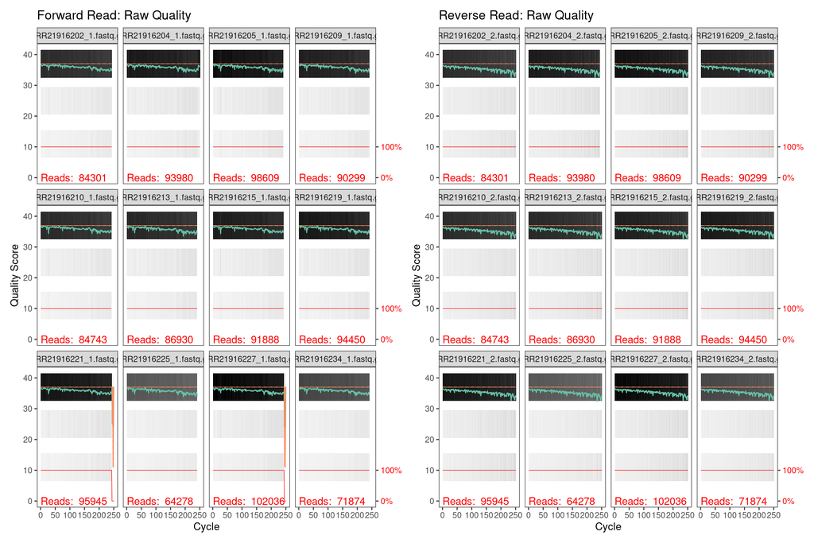

```r
# Calculate and plot quality of these two samples
forward_filteredQual_plot_12 <- plotQualityProfile(forward_reads[random_samples]) +
  labs(title = "Forward Read: Raw Quality")
reverse_filteredQual_plot_12 <- plotQualityProfile(reverse_reads[random_samples]) +
  labs(title = "Reverse Read: Raw Quality")
# Plot them together with patchwork
forward_filteredQual_plot_12 + reverse_filteredQual_plot_12
```

### Aggregated Raw Quality Plots

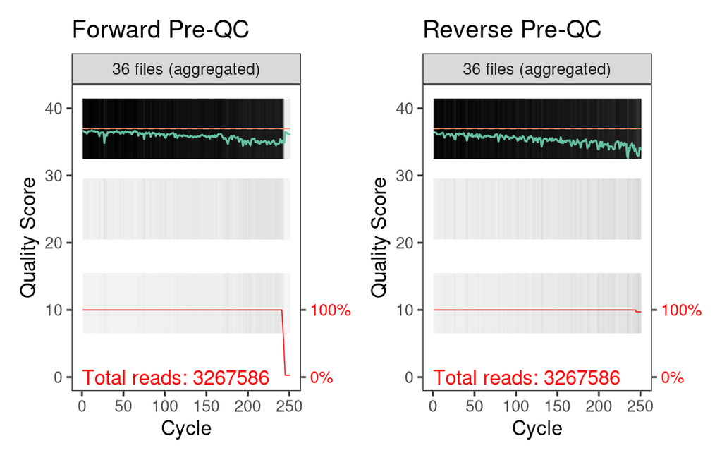

```r
# Aggregate all QC plots
# Forward reads
forward_preQC_plot <-
  plotQualityProfile(forward_reads, aggregate = TRUE) +
  labs(title = "Forward Pre-QC")
# reverse reads
reverse_preQC_plot <-
  plotQualityProfile(reverse_reads, aggregate = TRUE) +
  labs(title = "Reverse Pre-QC")

preQC_aggregate_plot <-
  # Plot the forward and reverse together
  forward_preQC_plot + reverse_preQC_plot

# Show the plot
preQC_aggregate_plot
```

## Prepare a placeholder for filtered reads

```r
# vector of our samples, extract sample name from files
samples <- sapply(strsplit(basename(forward_reads), "_"), `[`,1)
# Intuition Check
head(samples)
```

```
## [1] "SRR21916202" "SRR21916203" "SRR21916204" "SRR21916205" "SRR21916206"
## [6] "SRR21916207"
```

```r
# Place filtered reads into filtered_fastqs_path
filtered_fastqs_path <- "data/01_DADA2/02_filtered_fastqs"
filtered_fastqs_path
```

```
## [1] "data/01_DADA2/02_filtered_fastqs"
```

```r
# create 2 variables: filtered_F, filtered_R
filtered_forward_reads <-
  file.path(filtered_fastqs_path, paste0(samples, "_1_filtered.fastq.gz"))
length(filtered_forward_reads)
```

```
## [1] 36
```

```r
# reverse reads
filtered_reverse_reads <-
  file.path(filtered_fastqs_path, paste0(samples, "_2_filtered.fastq.gz"))
head(filtered_reverse_reads)
```

```
## [1] "data/01_DADA2/02_filtered_fastqs/SRR21916202_2_filtered.fastq.gz"
## [2] "data/01_DADA2/02_filtered_fastqs/SRR21916203_2_filtered.fastq.gz"
## [3] "data/01_DADA2/02_filtered_fastqs/SRR21916204_2_filtered.fastq.gz"
## [4] "data/01_DADA2/02_filtered_fastqs/SRR21916205_2_filtered.fastq.gz"
## [5] "data/01_DADA2/02_filtered_fastqs/SRR21916206_2_filtered.fastq.gz"
## [6] "data/01_DADA2/02_filtered_fastqs/SRR21916207_2_filtered.fastq.gz"
```

# Filter and Trim Reads

- `maxEE` is a quality filtering threshold applied to expected errors. Here, if there’s 2 expected errors. It’s ok. But more than 2. Throw away the sequence. Two values, first is for forward reads; second is for reverse reads.
- `trimLeft` can be used to remove the beginning bases of a read *(Here used to trim out primers)*
- `truncLen` can be used to trim your sequences after a specific base pair when the quality gets lower. Though, please note that this will shorten the ASVs! For example, this can be used when the quality of the sequence suddenly gets lower, or clearly is typically lower. So, if the quality of the read drops below a phred score of 25 (on the y-axis of the plotQualityProfile above, which indicates ~99.5% confidence per base).
- `maxN` the number of N bases. Here, using ASVs, we should ALWAYS remove all Ns from the data.

```r
filtered_reads <- filterAndTrim(forward_reads, filtered_forward_reads,
              reverse_reads, filtered_reverse_reads,
              trimLeft = c(19,20),
              maxN = 0, maxEE = c(2,2), truncQ = 2,
              rm.phix = TRUE, compress = TRUE,
               multithread = 5)
```

# Assess Trimmed Read Quality

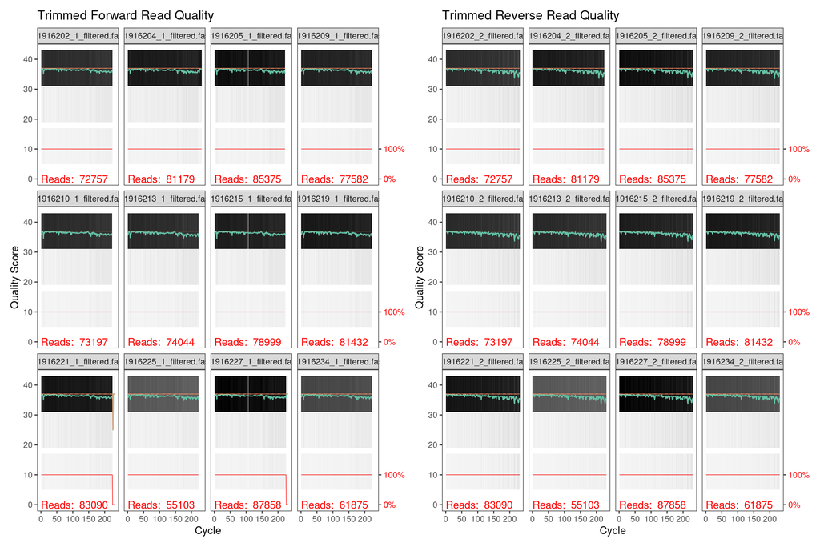

```r
# Plot the 12 random samples after QC
forward_filteredQual_plot_12 <-
  plotQualityProfile(filtered_forward_reads[random_samples]) +
  labs(title = "Trimmed Forward Read Quality")

reverse_filteredQual_plot_12 <-
  plotQualityProfile(filtered_reverse_reads[random_samples]) +
  labs(title = "Trimmed Reverse Read Quality")

# Put the two plots together
forward_filteredQual_plot_12 + reverse_filteredQual_plot_12
```

## Aggregated Trimmed Plots

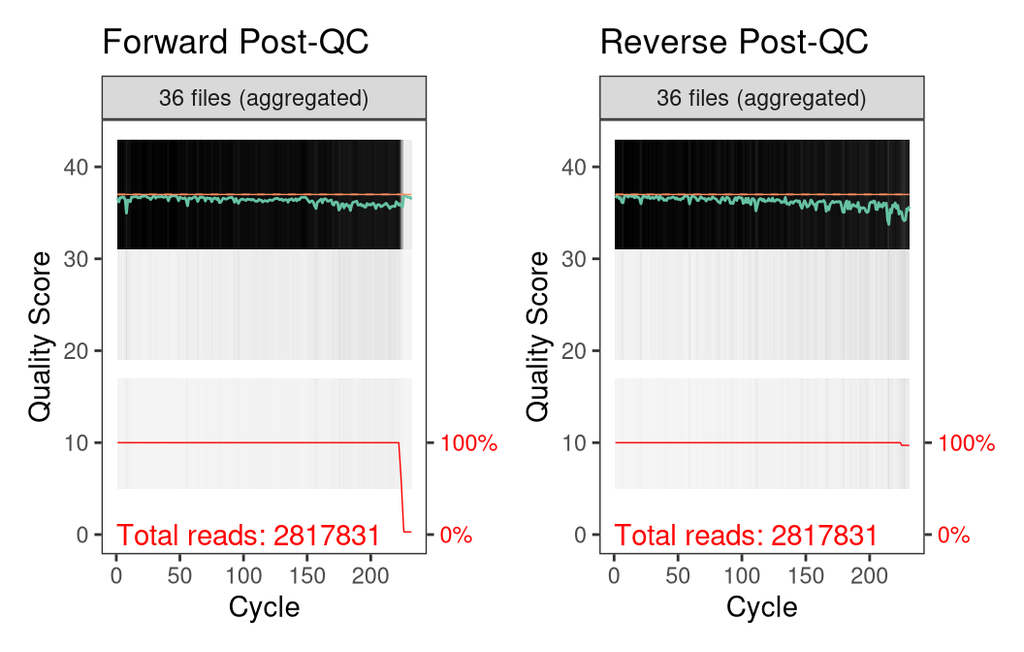

```r
# Aggregate all QC plots
# Forward reads
forward_postQC_plot <-
  plotQualityProfile(filtered_forward_reads, aggregate = TRUE) +
  labs(title = "Forward Post-QC")

# reverse reads
reverse_postQC_plot <-
  plotQualityProfile(filtered_reverse_reads, aggregate = TRUE) +
  labs(title = "Reverse Post-QC")

postQC_aggregate_plot <-
  # Plot the forward and reverse together
  forward_postQC_plot + reverse_postQC_plot

# Show the plot
postQC_aggregate_plot
```

The trimmed reads are of even higher quality than the raw reads, as expected. All Phred scores are above 30 and even before calculating read retention, it seems a fair number of reads were retained.

## Stats on read output from `filterAndTrim`

```r
# Make output into dataframe
filtered_df <- as.data.frame(filtered_reads)
head(filtered_df)
```

```
##                        reads.in reads.out
## SRR21916202_1.fastq.gz    84301     72757
## SRR21916203_1.fastq.gz    90262     78653
## SRR21916204_1.fastq.gz    93980     81179
## SRR21916205_1.fastq.gz    98609     85375
## SRR21916206_1.fastq.gz    98699     85615
## SRR21916207_1.fastq.gz    95172     82622
```

```r
# calculate some stats
filtered_df %>%
  reframe(median_reads_in = median(reads.in),
          median_reads_out = median(reads.out),
          median_percent_retained = (median(reads.out)/median(reads.in)))
```

```
##   median_reads_in median_reads_out median_percent_retained
## 1           91491            78715               0.8603578
```

86% of reads were retained though filtering. This seems like an acceptable retention level. Initially, I used trimRight = 3 to trim base 247 before noticing that the base quality was low only for one read. Surprisingly, this led to a slightly higher retention of 86.33% which I would not expect with an additional parameter which I interpreted as making the filtering step more stringent. I ultimately decided to use the command that did not include the trimRight parameter. Up until this point, the binned quality scores generated by the Illumina Novaseq platform do not seem incompatible with this workflow. However, the error modeling step will need to account for the binned quality scores in order to use the estimated error rates for inferring ASVs. When the first error estimation model was used for inferring ASVs, only 16 ASVs were detected.

# First Attempt

```r
# Forward reads
#error_forward_reads <-
#  learnErrors(filtered_forward_reads, multithread = 5)
# Plot Forward
#forward_error_plot <-
#  plotErrors(error_forward_reads, nominalQ = TRUE) +
#  labs(title = "Forward Read Error Model")

# Reverse reads
#error_reverse_reads <-
#  learnErrors(filtered_reverse_reads, multithread = 5)
# Plot reverse
#reverse_error_plot <-
#  plotErrors(error_reverse_reads, nominalQ = TRUE) +
#  labs(title = "Reverse Read Error Model")

# Put the two plots together
#forward_error_plot + reverse_error_plot
```

The DADA2 learnErrors command was found to be incompatible for data with binned quality scores. I consulted a github forum discussing the issue (https://github.com/benjjneb/dada2/issues/1307). Proposed solutions included using the loessErrfun function enforcing monotonicity. I used a code shared by JacobRPrice from this forum.

# Second Attempt

```r
library(magrittr)
```

```r
library(dplyr)

loessErrfun_mod <- function(trans) {
  qq <- as.numeric(colnames(trans))
  est <- matrix(0, nrow=0, ncol=length(qq))
  for(nti in c("A","C","G","T")) {
    for(ntj in c("A","C","G","T")) {
      if(nti != ntj) {
        errs <- trans[paste0(nti,"2",ntj),]
        tot <- colSums(trans[paste0(nti,"2",c("A","C","G","T")),])
        rlogp <- log10((errs+1)/tot)  # 1 psuedocount for each err, but if tot=0 will give NA
        rlogp[is.infinite(rlogp)] <- NA
        df <- data.frame(q=qq, errs=errs, tot=tot, rlogp=rlogp)

        # original
        # ###! mod.lo <- loess(rlogp ~ q, df, weights=errs) ###!
        # mod.lo <- loess(rlogp ~ q, df, weights=tot) ###!
        # #        mod.lo <- loess(rlogp ~ q, df)

        # Gulliem Salazar's solution
        # https://github.com/benjjneb/dada2/issues/938
        # mod.lo <- loess(rlogp ~ q, df, weights = log10(tot),span = 2)

        # only change the weights
        mod.lo <- loess(rlogp ~ q, df, weights = log10(tot))

        pred <- predict(mod.lo, qq)
        maxrli <- max(which(!is.na(pred)))
        minrli <- min(which(!is.na(pred)))
        pred[seq_along(pred)>maxrli] <- pred[[maxrli]]
        pred[seq_along(pred)<minrli] <- pred[[minrli]]
        est <- rbind(est, 10^pred)
      } # if(nti != ntj)
    } # for(ntj in c("A","C","G","T"))
  } # for(nti in c("A","C","G","T"))

  # HACKY
  MAX_ERROR_RATE <- 0.25
  MIN_ERROR_RATE <- 1e-7
  est[est>MAX_ERROR_RATE] <- MAX_ERROR_RATE
  est[est<MIN_ERROR_RATE] <- MIN_ERROR_RATE

  # enforce monotonicity
  # https://github.com/benjjneb/dada2/issues/791
  estorig <- est
  est <- est %>%
    data.frame() %>%
    mutate_all(funs(case_when(. < X40 ~ X40,
                              . >= X40 ~ .))) %>% as.matrix()
  rownames(est) <- rownames(estorig)
  colnames(est) <- colnames(estorig)

  # Expand the err matrix with the self-transition probs
  err <- rbind(1-colSums(est[1:3,]), est[1:3,],
               est[4,], 1-colSums(est[4:6,]), est[5:6,],
               est[7:8,], 1-colSums(est[7:9,]), est[9,],
               est[10:12,], 1-colSums(est[10:12,]))
  rownames(err) <- paste0(rep(c("A","C","G","T"), each=4), "2", c("A","C","G","T"))
  colnames(err) <- colnames(trans)
  # Return
  return(err)
}

# check what this looks like
errF <- learnErrors(filtered_forward_reads
  ,
  multithread = 5,
  errorEstimationFunction = loessErrfun_mod,
  verbose = TRUE
)
```

```
## 109284298 total bases in 486201 reads from 6 samples will be used for learning the error rates.
## Initializing error rates to maximum possible estimate.
## selfConsist step 1 ......
##    selfConsist step 2
##    selfConsist step 3
##    selfConsist step 4
##    selfConsist step 5
##    selfConsist step 6
##    selfConsist step 7
##    selfConsist step 8
##    selfConsist step 9
##    selfConsist step 10
```

```
## Self-consistency loop terminated before convergence.
```

```r
errR <- learnErrors(filtered_reverse_reads
  ,
  multithread = 5,
  errorEstimationFunction = loessErrfun_mod,
  verbose = TRUE
)
```

```
## 111735870 total bases in 486201 reads from 6 samples will be used for learning the error rates.
## Initializing error rates to maximum possible estimate.
## selfConsist step 1 ......
##    selfConsist step 2
##    selfConsist step 3
##    selfConsist step 4
##    selfConsist step 5
##    selfConsist step 6
##    selfConsist step 7
##    selfConsist step 8
##    selfConsist step 9
##    selfConsist step 10
```

```
## Self-consistency loop terminated before convergence.
```

```r
dada2:::checkConvergence(errR)
```

```
##  [1] 55.513438279  4.185588649  0.553108057  0.057590098  0.003930631
##  [6]  0.004259903  0.001953206  0.003530471  0.002415959  0.003513314
```

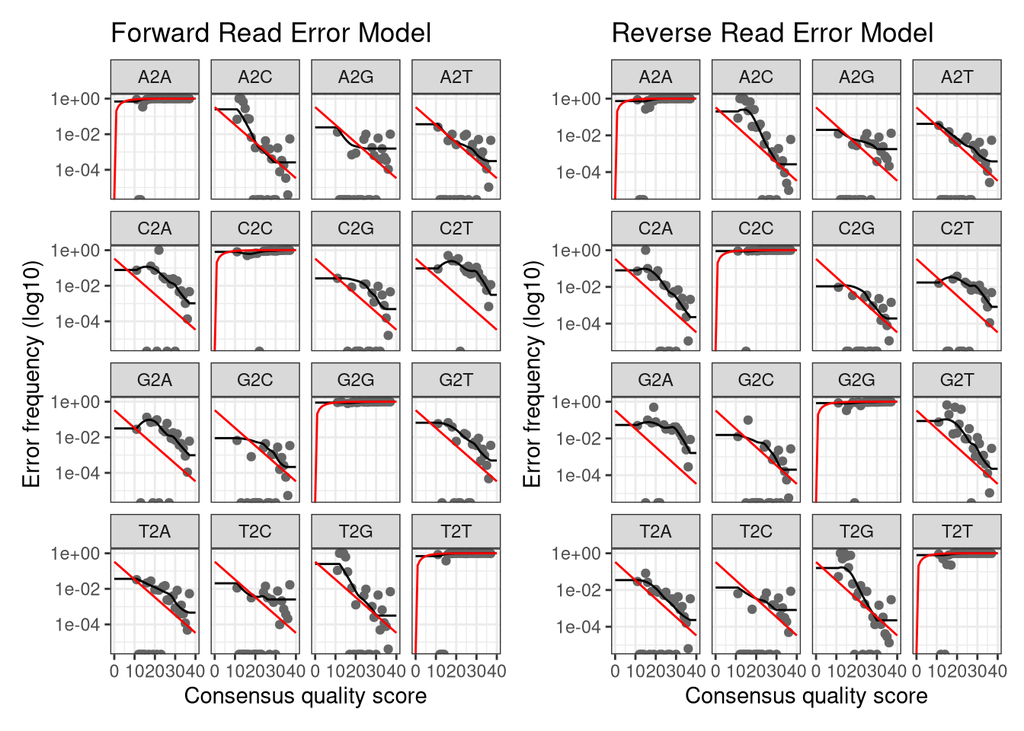

```r
forward_error_plot <-
 plotErrors(errF, nominalQ = TRUE) +
 labs(title = "Forward Read Error Model")

reverse_error_plot <-
 plotErrors(errR, nominalQ = TRUE) +
 labs(title = "Reverse Read Error Model")
forward_error_plot + reverse_error_plot
```

```r
# Success!
```

This error model looks much more reasonable than the prior model which had “dips” in the estimated error rates caused by binned quality scores. As expected, error rates decrease as quality scores increase. These error estimates can now be applied to the DADA function for inferring ASVs.

# Infer ASVs

```r
#Infer ASVs on the forward sequences
dada_forward <- dada(filtered_forward_reads,
                     err = errF,
                     multithread = 5)
```

```
## Sample 1 - 72757 reads in 40306 unique sequences.
## Sample 2 - 78653 reads in 38197 unique sequences.
## Sample 3 - 81179 reads in 44163 unique sequences.
## Sample 4 - 85375 reads in 40984 unique sequences.
## Sample 5 - 85615 reads in 43939 unique sequences.
## Sample 6 - 82622 reads in 44574 unique sequences.
## Sample 7 - 79185 reads in 43348 unique sequences.
## Sample 8 - 77582 reads in 40655 unique sequences.
## Sample 9 - 73197 reads in 40232 unique sequences.
## Sample 10 - 84368 reads in 42896 unique sequences.
## Sample 11 - 78245 reads in 42176 unique sequences.
## Sample 12 - 74044 reads in 41339 unique sequences.
## Sample 13 - 84966 reads in 47072 unique sequences.
## Sample 14 - 78999 reads in 41946 unique sequences.
## Sample 15 - 74660 reads in 41882 unique sequences.
## Sample 16 - 73746 reads in 42911 unique sequences.
## Sample 17 - 82860 reads in 45504 unique sequences.
## Sample 18 - 81432 reads in 45102 unique sequences.
## Sample 19 - 77282 reads in 43783 unique sequences.
## Sample 20 - 83090 reads in 46763 unique sequences.
## Sample 21 - 82823 reads in 46644 unique sequences.
## Sample 22 - 74484 reads in 39160 unique sequences.
## Sample 23 - 88917 reads in 49425 unique sequences.
## Sample 24 - 55103 reads in 36124 unique sequences.
## Sample 25 - 82747 reads in 46588 unique sequences.
## Sample 26 - 87858 reads in 53471 unique sequences.
## Sample 27 - 74292 reads in 38010 unique sequences.
## Sample 28 - 76613 reads in 41952 unique sequences.
## Sample 29 - 71875 reads in 37217 unique sequences.
## Sample 30 - 78777 reads in 41901 unique sequences.
## Sample 31 - 77160 reads in 39571 unique sequences.
## Sample 32 - 84843 reads in 45122 unique sequences.
## Sample 33 - 61875 reads in 35284 unique sequences.
## Sample 34 - 74216 reads in 40698 unique sequences.
## Sample 35 - 71729 reads in 41070 unique sequences.
## Sample 36 - 84662 reads in 49618 unique sequences.
```

```r
# Inspect
dada_forward[1]
```

```
## $SRR21916202_1_filtered.fastq.gz
## dada-class: object describing DADA2 denoising results
## 1898 sequence variants were inferred from 40306 input unique sequences.
## Key parameters: OMEGA_A = 1e-40, OMEGA_C = 1e-40, BAND_SIZE = 16
```

```r
dada_forward[30]
```

```
## $SRR21916231_1_filtered.fastq.gz
## dada-class: object describing DADA2 denoising results
## 1944 sequence variants were inferred from 41901 input unique sequences.
## Key parameters: OMEGA_A = 1e-40, OMEGA_C = 1e-40, BAND_SIZE = 16
```

```r
dada_reverse <- dada(filtered_reverse_reads,
                     err = errR,
                     multithread = 5)
```

```
## Sample 1 - 72757 reads in 31546 unique sequences.
## Sample 2 - 78653 reads in 29108 unique sequences.
## Sample 3 - 81179 reads in 32903 unique sequences.
## Sample 4 - 85375 reads in 30918 unique sequences.
## Sample 5 - 85615 reads in 34249 unique sequences.
## Sample 6 - 82622 reads in 33953 unique sequences.
## Sample 7 - 79185 reads in 33197 unique sequences.
## Sample 8 - 77582 reads in 31197 unique sequences.
## Sample 9 - 73197 reads in 31310 unique sequences.
## Sample 10 - 84368 reads in 32429 unique sequences.
## Sample 11 - 78245 reads in 32227 unique sequences.
## Sample 12 - 74044 reads in 31345 unique sequences.
## Sample 13 - 84966 reads in 35999 unique sequences.
## Sample 14 - 78999 reads in 32426 unique sequences.
## Sample 15 - 74660 reads in 31887 unique sequences.
## Sample 16 - 73746 reads in 32297 unique sequences.
## Sample 17 - 82860 reads in 34870 unique sequences.
## Sample 18 - 81432 reads in 33935 unique sequences.
## Sample 19 - 77282 reads in 33471 unique sequences.
## Sample 20 - 83090 reads in 36455 unique sequences.
## Sample 21 - 82823 reads in 36352 unique sequences.
## Sample 22 - 74484 reads in 29498 unique sequences.
## Sample 23 - 88917 reads in 38374 unique sequences.
## Sample 24 - 55103 reads in 28758 unique sequences.
## Sample 25 - 82747 reads in 36141 unique sequences.
## Sample 26 - 87858 reads in 40979 unique sequences.
## Sample 27 - 74292 reads in 29060 unique sequences.
## Sample 28 - 76613 reads in 32146 unique sequences.
## Sample 29 - 71875 reads in 28045 unique sequences.
## Sample 30 - 78777 reads in 32537 unique sequences.
## Sample 31 - 77160 reads in 30351 unique sequences.
## Sample 32 - 84843 reads in 34641 unique sequences.
## Sample 33 - 61875 reads in 27179 unique sequences.
## Sample 34 - 74216 reads in 31541 unique sequences.
## Sample 35 - 71729 reads in 31916 unique sequences.
## Sample 36 - 84662 reads in 38780 unique sequences.
```

```r
# Inspect
dada_reverse[1]
```

```
## $SRR21916202_2_filtered.fastq.gz
## dada-class: object describing DADA2 denoising results
## 2169 sequence variants were inferred from 31546 input unique sequences.
## Key parameters: OMEGA_A = 1e-40, OMEGA_C = 1e-40, BAND_SIZE = 16
```

```r
dada_reverse[30]
```

```
## $SRR21916231_2_filtered.fastq.gz
## dada-class: object describing DADA2 denoising results
## 2270 sequence variants were inferred from 32537 input unique sequences.
## Key parameters: OMEGA_A = 1e-40, OMEGA_C = 1e-40, BAND_SIZE = 16
```

# Merge Forward & Reverse ASVs

Now, merge the forward and reverse ASVs into contigs.

```r
# merge forward and reverse ASVs
merged_ASVs <- mergePairs(dada_forward, filtered_forward_reads,
                          dada_reverse, filtered_reverse_reads,
                          verbose = TRUE)
```

```
## 35826 paired-reads (in 4298 unique pairings) successfully merged out of 57819 (in 20178 pairings) input.
```

```
## 46001 paired-reads (in 4602 unique pairings) successfully merged out of 65504 (in 18576 pairings) input.
```

```
## 0 paired-reads (in 0 unique pairings) successfully merged out of 66734 (in 21320 pairings) input.
```

```
## 50008 paired-reads (in 4561 unique pairings) successfully merged out of 72786 (in 20532 pairings) input.
```

```
## 45951 paired-reads (in 5187 unique pairings) successfully merged out of 70140 (in 22736 pairings) input.
```

```
## 42658 paired-reads (in 4856 unique pairings) successfully merged out of 66648 (in 22219 pairings) input.
```

```
## 39858 paired-reads (in 4568 unique pairings) successfully merged out of 64112 (in 21770 pairings) input.
```

```
## 40935 paired-reads (in 4688 unique pairings) successfully merged out of 64474 (in 21376 pairings) input.
```

```
## 36406 paired-reads (in 4393 unique pairings) successfully merged out of 58811 (in 20258 pairings) input.
```

```
## 46807 paired-reads (in 4980 unique pairings) successfully merged out of 70230 (in 21531 pairings) input.
```

```
## 39862 paired-reads (in 4647 unique pairings) successfully merged out of 64359 (in 21886 pairings) input.
```

```
## 36995 paired-reads (in 4512 unique pairings) successfully merged out of 60164 (in 20949 pairings) input.
```

```
## 42154 paired-reads (in 4777 unique pairings) successfully merged out of 67066 (in 22863 pairings) input.
```

```
## 41427 paired-reads (in 4674 unique pairings) successfully merged out of 64133 (in 20897 pairings) input.
```

```
## 35985 paired-reads (in 4467 unique pairings) successfully merged out of 59563 (in 21604 pairings) input.
```

```
## 34858 paired-reads (in 4184 unique pairings) successfully merged out of 58419 (in 21058 pairings) input.
```

```
## 41324 paired-reads (in 4801 unique pairings) successfully merged out of 66236 (in 22731 pairings) input.
```

```
## 40993 paired-reads (in 4673 unique pairings) successfully merged out of 65739 (in 22427 pairings) input.
```

```
## 37025 paired-reads (in 4892 unique pairings) successfully merged out of 61568 (in 22608 pairings) input.
```

```
## 40090 paired-reads (in 5027 unique pairings) successfully merged out of 65268 (in 23217 pairings) input.
```

```
## 39040 paired-reads (in 5032 unique pairings) successfully merged out of 64951 (in 23923 pairings) input.
```

```
## 40264 paired-reads (in 4303 unique pairings) successfully merged out of 61963 (in 19646 pairings) input.
```

```
## 42722 paired-reads (in 5315 unique pairings) successfully merged out of 70941 (in 26021 pairings) input.
```

```
## 22853 paired-reads (in 3471 unique pairings) successfully merged out of 40310 (in 15691 pairings) input.
```

```
## 39338 paired-reads (in 4929 unique pairings) successfully merged out of 64944 (in 23545 pairings) input.
```

```
## 36739 paired-reads (in 5026 unique pairings) successfully merged out of 66531 (in 26708 pairings) input.
```

```
## 41248 paired-reads (in 4606 unique pairings) successfully merged out of 61219 (in 18779 pairings) input.
```

```
## 38434 paired-reads (in 4517 unique pairings) successfully merged out of 61249 (in 21088 pairings) input.
```

```
## 40391 paired-reads (in 3702 unique pairings) successfully merged out of 59534 (in 17255 pairings) input.
```

```
## 41075 paired-reads (in 4794 unique pairings) successfully merged out of 63639 (in 21354 pairings) input.
```

```
## 42264 paired-reads (in 4369 unique pairings) successfully merged out of 63012 (in 19045 pairings) input.
```

```
## 44112 paired-reads (in 4810 unique pairings) successfully merged out of 68280 (in 22228 pairings) input.
```

```
## 30161 paired-reads (in 3976 unique pairings) successfully merged out of 48677 (in 17311 pairings) input.
```

```
## 37329 paired-reads (in 4562 unique pairings) successfully merged out of 59592 (in 20858 pairings) input.
```

```
## 33982 paired-reads (in 4390 unique pairings) successfully merged out of 55920 (in 20387 pairings) input.
```

```
## 37761 paired-reads (in 5533 unique pairings) successfully merged out of 64781 (in 25603 pairings) input.
```

```r
# Evaluate the output
typeof(merged_ASVs)
```

```
## [1] "list"
```

```r
length(merged_ASVs)
```

```
## [1] 36
```

```r
names(merged_ASVs)
```

```
##  [1] "SRR21916202_1_filtered.fastq.gz" "SRR21916203_1_filtered.fastq.gz"
##  [3] "SRR21916204_1_filtered.fastq.gz" "SRR21916205_1_filtered.fastq.gz"
##  [5] "SRR21916206_1_filtered.fastq.gz" "SRR21916207_1_filtered.fastq.gz"
##  [7] "SRR21916208_1_filtered.fastq.gz" "SRR21916209_1_filtered.fastq.gz"
##  [9] "SRR21916210_1_filtered.fastq.gz" "SRR21916211_1_filtered.fastq.gz"
## [11] "SRR21916212_1_filtered.fastq.gz" "SRR21916213_1_filtered.fastq.gz"
## [13] "SRR21916214_1_filtered.fastq.gz" "SRR21916215_1_filtered.fastq.gz"
## [15] "SRR21916216_1_filtered.fastq.gz" "SRR21916217_1_filtered.fastq.gz"
## [17] "SRR21916218_1_filtered.fastq.gz" "SRR21916219_1_filtered.fastq.gz"
## [19] "SRR21916220_1_filtered.fastq.gz" "SRR21916221_1_filtered.fastq.gz"
## [21] "SRR21916222_1_filtered.fastq.gz" "SRR21916223_1_filtered.fastq.gz"
## [23] "SRR21916224_1_filtered.fastq.gz" "SRR21916225_1_filtered.fastq.gz"
## [25] "SRR21916226_1_filtered.fastq.gz" "SRR21916227_1_filtered.fastq.gz"
## [27] "SRR21916228_1_filtered.fastq.gz" "SRR21916229_1_filtered.fastq.gz"
## [29] "SRR21916230_1_filtered.fastq.gz" "SRR21916231_1_filtered.fastq.gz"
## [31] "SRR21916232_1_filtered.fastq.gz" "SRR21916233_1_filtered.fastq.gz"
## [33] "SRR21916234_1_filtered.fastq.gz" "SRR21916235_1_filtered.fastq.gz"
## [35] "SRR21916236_1_filtered.fastq.gz" "SRR21916237_1_filtered.fastq.gz"
```

```r
# Inspect the merger data.frame from the 20210602-MA-ABB1P
head(merged_ASVs[[3]])
```

```
## [1] sequence  abundance forward   reverse   nmatch    nmismatch nindel
## [8] prefer    accept
## <0 rows> (or 0-length row.names)
```